# MD5

```r
library(tidyverse)
library(moderndive)
library(skimr)
library(gapminder)
```

```r
library(tidyverse)

twitch_data <- read_csv("https://raw.githubusercontent.com/vaiseys/dav-course/main/Data/twitchdata-update.csv")
```

```r
library(janitor)
twitch_data <- clean_names(twitch_data)

# Inspect new names
colnames(twitch_data)
```

```
 [1] "channel"             "watch_time_minutes"  "stream_time_minutes"
 [4] "peak_viewers"        "average_viewers"     "followers"
 [7] "followers_gained"    "views_gained"        "partnered"
[10] "mature"              "language"
```

```r
twitch_data %>%
sample_n(size = 5)
```

```
# A tibble: 5 × 11
  channel    watch_time_minutes stream_time_minutes peak_viewers average_viewers
  <chr>                   <dbl>               <dbl>        <dbl>           <dbl>
1 GN_GG               185795730              108075         4859            1715
2 WOKE                235303170               51600        50598            3827
3 핑맨 (95p…          164673495               47430        26738            3449
4 嬌兔 (zru…          436243530              137910        10628            3084
5 Xayoo_              575138175               91260        23935            6091
# ℹ 6 more variables: followers <dbl>, followers_gained <dbl>,
#   views_gained <dbl>, partnered <lgl>, mature <lgl>, language <chr>
```

Q.1 Part a)

Q:Describe the results in a few words. Does anything capture your attention?

A:They all have very large watch time minutes but some have very low average viewers.

```r
twitch_data %>%
  select(average_viewers, followers) %>%
  summary()
```

```
 average_viewers    followers
 Min.   :   235   Min.   :   3660
 1st Qu.:  1458   1st Qu.: 170546
 Median :  2425   Median : 318063
 Mean   :  4781   Mean   : 570054
 3rd Qu.:  4786   3rd Qu.: 624332
 Max.   :147643   Max.   :8938903
```

Q.1 Part b)

Q:Does anything capture your attention?

A: The amount of followers doesn’t equal amount of average viewers.

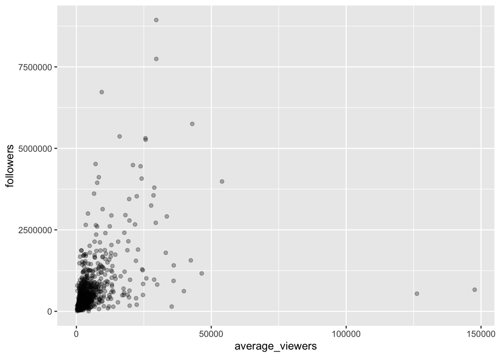

```r
ggplot(twitch_data,
aes(x = average_viewers,
    y = followers)) +
  geom_jitter(alpha = .3)
```

Q.1 Part c)

Q: What do you notice? (scatterplot)

A: The points are very clustered at the bottom left.

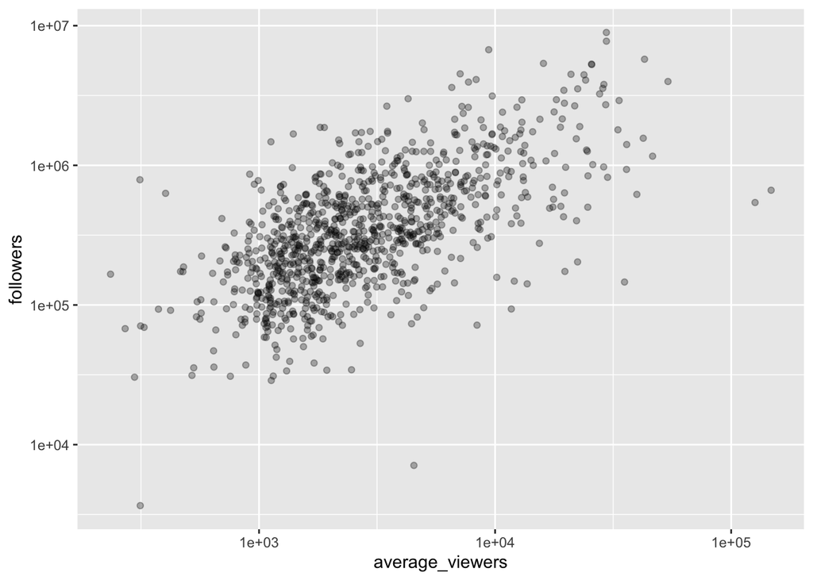

```r
ggplot(twitch_data,
aes(x = average_viewers,
    y = followers)) +
  geom_jitter(alpha = .3) +
 scale_x_log10() +
  scale_y_log10()
```

Q.1 Part d)

Q: What do you see now? How does the relationship look like?

A: They are a lot more open and up to scale and it looks like a positive relationship.

```r
twitch_data <- twitch_data %>%
  mutate(log_viewers = log10(average_viewers),
         log_followers = log10(followers))
```

Q.2)

```r
fit1 <- lm(log_viewers ~ log_followers, data = twitch_data)
get_regression_table(fit1)
```

```
# A tibble: 2 × 7
  term          estimate std_error statistic p_value lower_ci upper_ci
  <chr>            <dbl>     <dbl>     <dbl>   <dbl>    <dbl>    <dbl>
1 intercept        0.198     0.125      1.58   0.115   -0.048    0.444
2 log_followers    0.588     0.023     26.0    0        0.544    0.633
```

Q.2 Part a)

Q:Take the coefficient from your model and interpret it in this way.

Equation: $$ 1.1^(.588) = 1.057

A: A 10% increase in followers is associated with a 5.7% increase in the average number of viewers

Q.3)

```r
library(broom)

pred_data <- augment(fit1)

# glimpse our new data
glimpse(pred_data)
```

```
Rows: 1,000
Columns: 8
$ log_viewers   <dbl> 4.442731, 4.408410, 4.040444, 3.887280, 4.471321, 4.6275…
$ log_followers <dbl> 6.511388, 6.725108, 6.247393, 6.596030, 6.951284, 6.1940…
$ .fitted       <dbl> 4.029761, 4.155534, 3.874400, 4.079572, 4.288638, 3.8430…
$ .resid        <dbl> 0.4129697, 0.2528757, 0.1660436, -0.1922928, 0.1826833, …
$ .hat          <dbl> 0.006194481, 0.008694557, 0.003782169, 0.007126066, 0.01…
$ .sigma        <dbl> 0.3085580, 0.3087321, 0.3087919, 0.3087764, 0.3087820, 0…
$ .cooksd       <dbl> 0.0056128779, 0.0029688873, 0.0005513456, 0.0014026033, …
$ .std.resid    <dbl> 1.3420109, 0.8227954, 0.5389316, -0.6251793, 0.5953620, …
```

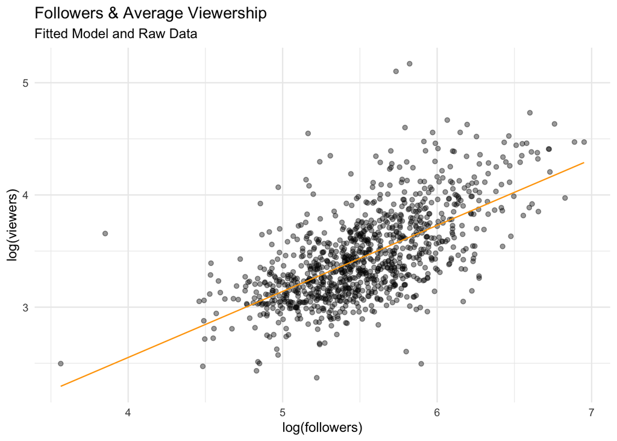

```r
pred_data %>%
  ggplot(aes(x = log_followers,
             y = log_viewers)) +
  geom_jitter(alpha = 0.4) +
  geom_line(aes(x = log_followers,
                y = .fitted),
            col = "orange") +
  theme_minimal() +
  labs(subtitle = "Fitted Model and Raw Data",
       title = "Followers & Average Viewership",
       x = "log(followers)",
       y = "log(viewers)")
```

Q.3 Part A)

Q:Do you think our model describes the relationship well?

A: Yes, it goes through the majority of the function.

Q.3 Part B)

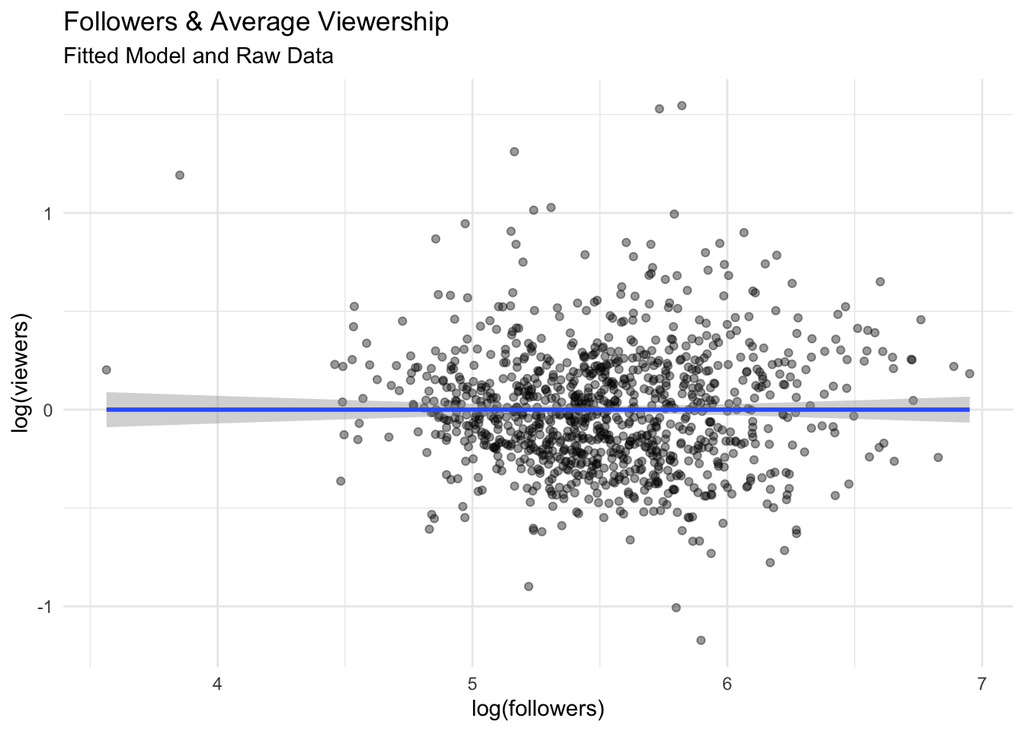

```r
pred_data %>%
  ggplot(aes(x = log_followers,
             y = .resid)) +
  geom_jitter(alpha = 0.4) +
  geom_smooth(method = lm) +
  theme_minimal() +
  labs(subtitle = "Fitted Model and Raw Data",
       title = "Followers & Average Viewership",
       x = "log(followers)",
       y = "log(viewers)")
```

Q: What do you see? Are there any big residuals? DO they happen often in a particular range of our x-variable? If so, we would have a problem: our model would systematically fail to predict part of our data.

A: There are some residuals off of the line but its normal going through the plot. They are often but they are mostly close to the line of best fit.

Q.4)

```r
fit2 <- lm(log_viewers ~ language, data = twitch_data)
get_regression_table(fit2)
```

```
# A tibble: 21 × 7
   term                estimate std_error statistic p_value lower_ci upper_ci
   <chr>                  <dbl>     <dbl>     <dbl>   <dbl>    <dbl>    <dbl>
 1 intercept              3.73      0.177     21.1    0        3.38     4.08
 2 language: Chinese     -0.344     0.191     -1.80   0.072   -0.719    0.031
 3 language: Czech       -0.549     0.24      -2.29   0.022   -1.02    -0.079
 4 language: English     -0.264     0.178     -1.49   0.137   -0.613    0.085
 5 language: Finnish     -0.717     0.433     -1.65   0.098   -1.57     0.134
 6 language: French      -0.324     0.184     -1.76   0.078   -0.684    0.037
 7 language: German      -0.321     0.186     -1.73   0.084   -0.685    0.044
 8 language: Greek       -0.436     0.433     -1.01   0.315   -1.29     0.414
 9 language: Hungarian   -0.413     0.331     -1.25   0.213   -1.06     0.237
10 language: Italian     -0.471     0.201     -2.34   0.02    -0.866   -0.076
# ℹ 11 more rows
```

```r
tidy(fit2)
```

```
# A tibble: 21 × 5
   term              estimate std.error statistic  p.value
   <chr>                <dbl>     <dbl>     <dbl>    <dbl>
 1 (Intercept)          3.73      0.177     21.1  1.40e-81
 2 languageChinese     -0.344     0.191     -1.80 7.21e- 2
 3 languageCzech       -0.549     0.240     -2.29 2.21e- 2
 4 languageEnglish     -0.264     0.178     -1.49 1.37e- 1
 5 languageFinnish     -0.717     0.433     -1.65 9.84e- 2
 6 languageFrench      -0.324     0.184     -1.76 7.82e- 2
 7 languageGerman      -0.321     0.186     -1.73 8.43e- 2
 8 languageGreek       -0.436     0.433     -1.01 3.15e- 1
 9 languageHungarian   -0.413     0.331     -1.25 2.13e- 1
10 languageItalian     -0.471     0.201     -2.34 1.96e- 2
# ℹ 11 more rows
```

```r
q_four <- augment(fit2)
```

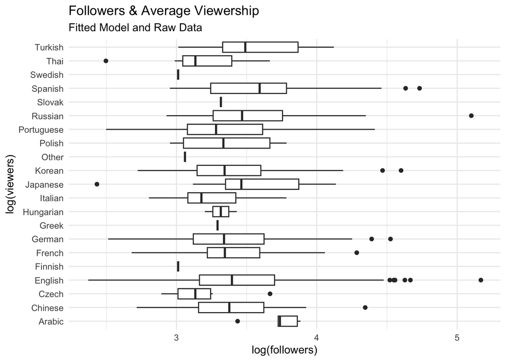

```r
q_four %>%
  ggplot(aes(x = log_viewers,
             y = language)) +
  geom_boxplot() +
  theme_minimal() +
  labs(subtitle = "Fitted Model and Raw Data",
       title = "Followers & Average Viewership",
       x = "log(followers)",
       y = "log(viewers)")
```

Q.5)

```r
twitch_data <- twitch_data %>%
  mutate(language = as.factor(language),
         language = relevel(language, ref = "English"))
```

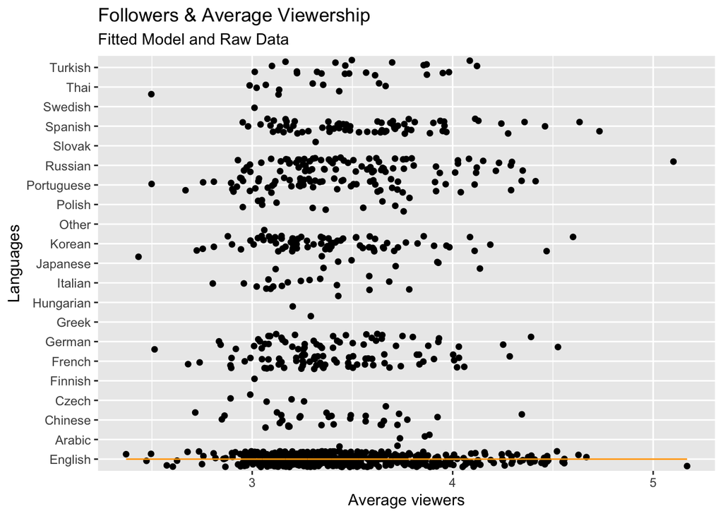

```r
twitch_data %>%
  ggplot(aes(x = log_viewers,
             y = language)) +
  geom_jitter() +
  geom_line(aes(x = log_viewers,
                y = "English"),
            col = "orange") +
  labs(subtitle = "Fitted Model and Raw Data",
       title = "Followers & Average Viewership",
       x = "Average viewers",
       y = "Languages")
```

Q:Interpret the results. How is my prediction doing?

Q.6)

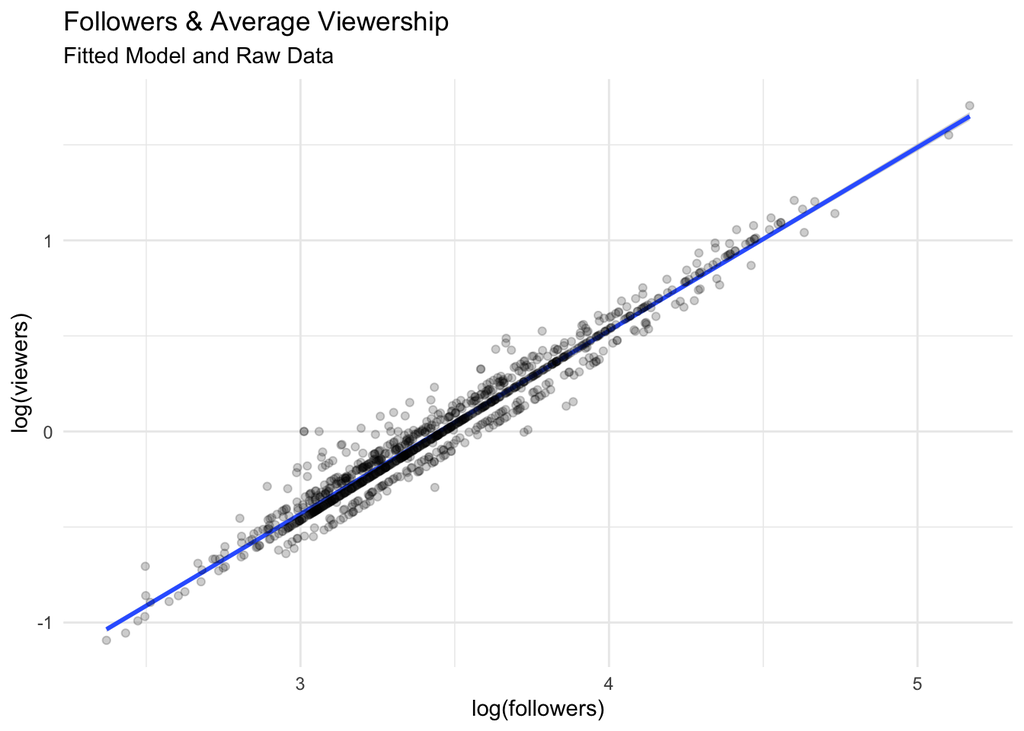

```r
q_four %>%
  ggplot(aes(x = log_viewers,
             y = .resid)) +
  geom_smooth(method = lm) +
  geom_jitter(alpha = .2) +
  theme_minimal() +
  labs(subtitle = "Fitted Model and Raw Data",
       title = "Followers & Average Viewership",
       x = "log(followers)",
       y = "log(viewers)")
```

Q:There are a couple of points our model really missed - which ones were they?